# TF-IDF

Vivian Liu

# 分析神鬼奇航三部曲

# (The Curse of the Black Pearl/Dead Man’s Chest/At the World’s End)

## STEP 1 載入所需套件

```r
library(readtext)
library(NLP)
library(tm)
library(SnowballC)
library(magrittr)
library(slam)
library(Matrix)
library(dplyr)
library(ggplot2)
library(tidytext)
library(RColorBrewer)
library(wordcloud)
library(jiebaRD)
library(jiebaR)
```

## STEP 2 匯入檔案

```r
doc1 <- readtext("C:\\Users\\user\\Downloads\\The_Curse_of_the_Black_Pearl-Irene_Trimble.txt")
doc2 <- readtext("C:\\Users\\user\\Downloads\\Dead_Mans_Chest-Irene_Trimble.txt")
doc3 <- readtext("C:\\Users\\user\\Downloads\\At_the_Worlds_End-Irene_Trimble.txt")
docAll <- data.frame(doc1,doc2,doc3)
```

## STEP 3 文本清理

```r
docs <- Corpus(VectorSource(docAll))
toSpace <- content_transformer(function(x, pattern) {
  return (gsub(pattern, " ", x))})
docs <- tm_map(docs,stripWhitespace)
docs <- tm_map(docs,removeNumbers)
docs <- tm_map(docs,removePunctuation)
docs <- tm_map(docs,tolower)
docs <- tm_map(docs,removeWords,stopwords("english"))
```

## STEP 4 tf-idf 計算

```r
tdm <- TermDocumentMatrix(docs, control = list(wordLengths = c(1, Inf)))
tf <- apply(tdm[,c(2,4,6)], 2, sum)
idfFun <- function(word_doc){ log2( (3) / nnzero(word_doc) ) }
idf <- apply(tdm[,c(2,4,6)], 1, idfFun)
doc.tfidf <- as.matrix(tdm[,c(2,4,6)])
for(i in 1:nrow(tdm)){
  for(j in 1:ncol(doc.tfidf)){
    doc.tfidf[i,j] <- (doc.tfidf[i,j] / tf[j]) * idf[i]
  }
}
```

## STEP 5 視覺化

### Ⅰ. The Curse of the Black Pearl

[figure not shown]

```r
m1 <- as.matrix(doc.tfidf[,1])
v <- sort(rowSums(m1), decreasing = TRUE)
d <- data.frame(word = names(v), freq = v)
#用文字雲看出現最多的詞彙
wordcloud(d$word, d$freq, max.words=50, random.order = F, ordered.colors = F,
          colors = rainbow(length(row.names(m1))))
```

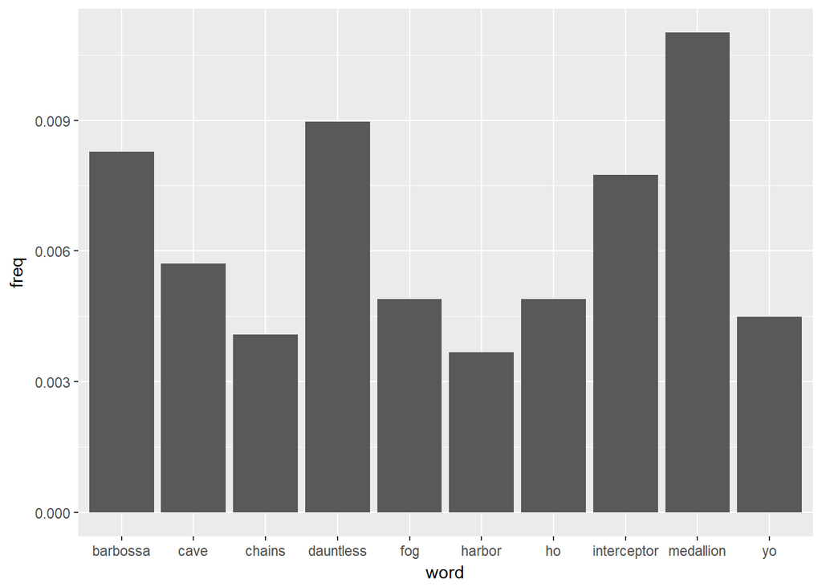

```r
#畫出前十名
ggplot(d[1:10,], aes(x= word,y= freq)) +
  geom_bar(stat = "identity")
```

### Ⅱ. Dead Man’s Chest

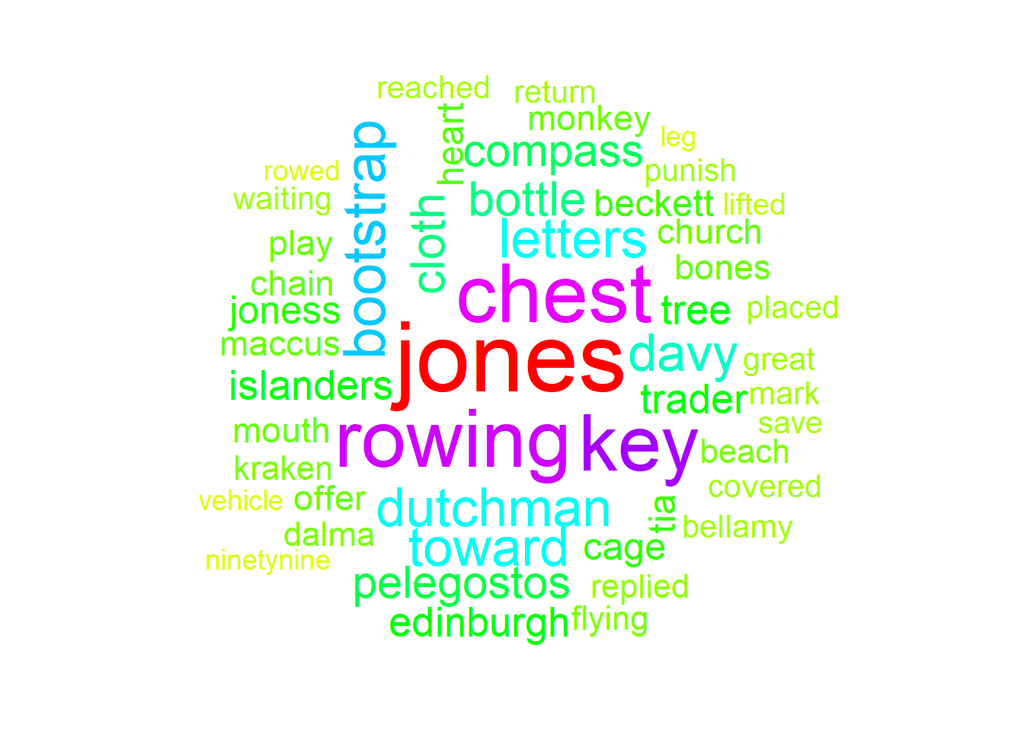

```r
m1 <- as.matrix(doc.tfidf[,2])
v <- sort(rowSums(m1), decreasing = TRUE)
d <- data.frame(word = names(v), freq = v)
#用文字雲看出現最多的詞彙
wordcloud(d$word, d$freq, max.words=50, random.order = F, ordered.colors = F,
          colors = rainbow(length(row.names(m1))))
```

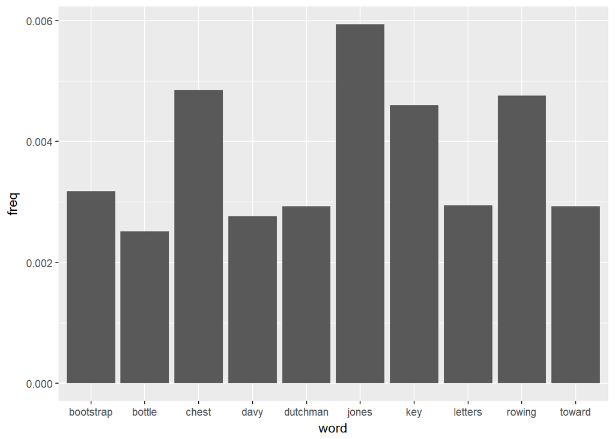

```r
#畫出前十名
ggplot(d[1:10,], aes(x= word,y= freq)) +
  geom_bar(stat = "identity")
```

### Ⅲ. At the World’s End

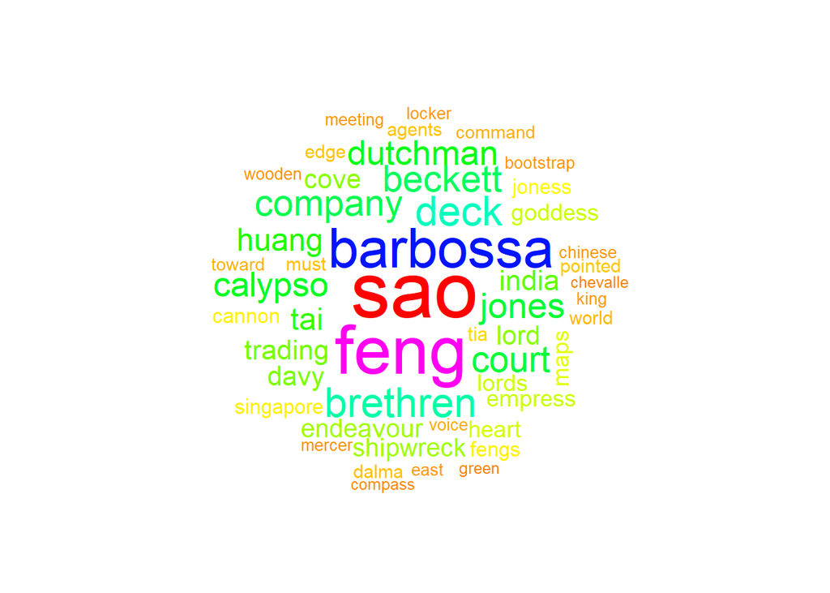

```r
m1 <- as.matrix(doc.tfidf[,3])
v <- sort(rowSums(m1), decreasing = TRUE)
d <- data.frame(word = names(v), freq = v)
#用文字雲看出現最多的詞彙
wordcloud(d$word, d$freq, max.words=50, random.order = F, ordered.colors = F,
          colors = rainbow(length(row.names(m1))))
```

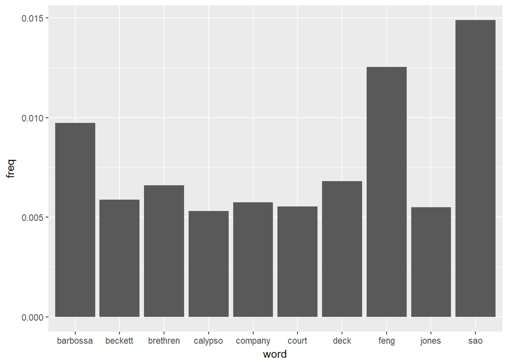

```r
#畫出前十名
ggplot(d[1:10,], aes(x= word,y= freq)) +
  geom_bar(stat = "identity")
```

### 三個結果都各自呈現該集最重要的關鍵字，鐵三角(Jack、Will、Elizabeth)因為是整個故事的主要角色因此被過濾掉，值得一提的我原本以為Barbossa船長屬於電影主要人物也會被過濾掉，結果他因為第一集死掉第三集復活回歸，因此他的名字在一、三集就變得很重要，我們從前十名的詞彙還可以看出與當集劇情最相關的人、事、物:

### 第一名的金幣(medallion)是第一集大家爭相搶奪的寶物，兩艘主要船艦的名字(Interceptor & Dauntless)和藏寶的洞穴(cave)一併出現在前十名，足以猜想第一集許多故事場景大多發生在這些地點。

### 第二集的劇情是一群人找尋Davy Jones的心臟，可以發現這故事的核心詞是chest & key，此外沒想到威爾的爸爸(Bootstrap)也是這個故事不可或缺的人物。

### 第三集的結果出現了許多新的角色，像是海神Calypso和由周潤發飾演的角色Sao Feng都成為這集重要的關鍵字，另外還有推動劇情的Brethren Court也在前十名之列。